# Snowshoe Hares in Bonanza Creek: Exploratory Report

### Visualize juvenile hare weights

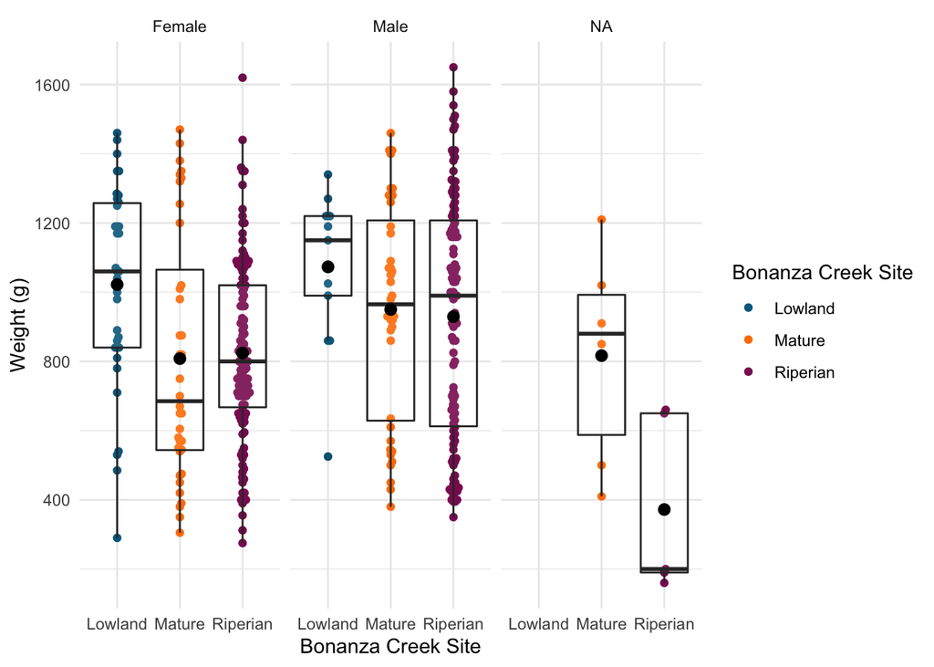

**Table 1.** Descriptive statistics (mean, median, standard deviation, and sample size) for juvenile hares observed in Bonanza Creek, by sex and site where trapped. Data: Kielland et al. (2017)

| Sex | Site | Mean weight (g) | Median weight (g) | Standard deviation (g) | Sample size |
| --- | --- | --- | --- | --- | --- |
| Female | Lowland | 1022.0588 | 1060 | 292.9632 | 34 |
| Female | Mature | 808.1944 | 685 | 361.1235 | 36 |
| Female | Riperian | 824.1496 | 800 | 255.0350 | 127 |
| Male | Lowland | 1073.0769 | 1150 | 222.6408 | 13 |
| Male | Mature | 950.1250 | 965 | 314.6864 | 40 |
| Male | Riperian | 929.2727 | 990 | 349.1660 | 110 |
| NA | Mature | 816.6667 | 880 | 307.0939 | 6 |
| NA | Riperian | 372.0000 | 200 | 258.7856 | 5 |

### Juvenile weight comparison (male and female snowshoe hares)

**Table 2.** Descriptive statistics (mean, median, standard deviation, and sample size) for juvenile hares observed in Bonanza Creek, by sex. Data: Kielland et al. (2017)

| Sex | Mean Weight (g) | Median Weight (g) | Standard Deviation (g) | Sample Size |
| --- | --- | --- | --- | --- |
| Female | 855.3909 | 825 | 292.2526 | 197 |
| Male | 945.8589 | 990 | 333.2151 | 163 |

### Relationship between juvenile weight and hind foot length

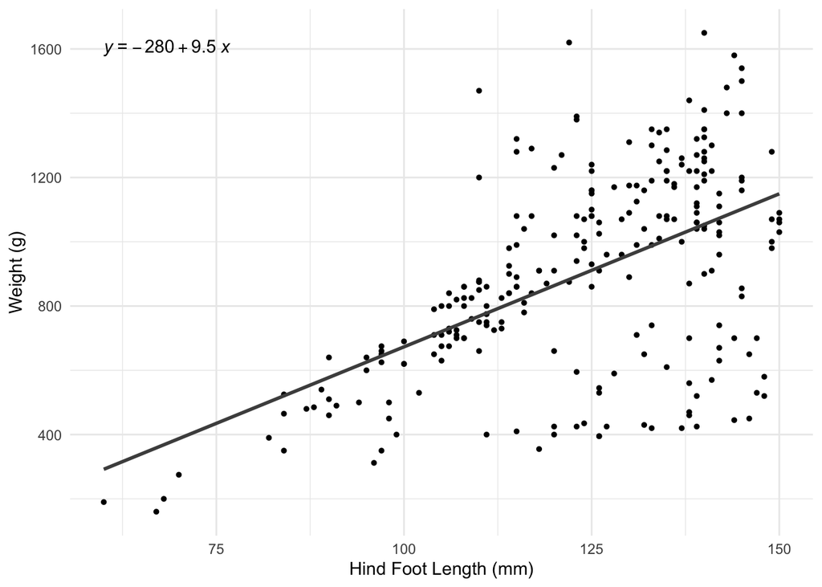

**Figure 3.** Relationship between hind foot length (mm) and weight (g) by for all juvenile hares trapped in Bonanza Creek and recorded for the study. Linear model summary: $\beta$<sub>1</sub> = 9.52 g mm<sup>-1</sup>, p < 0.001, R<sup>2</sup> = 0.3, Pearson’s *r* = 0.55). Data: Kielland et al. (2017)

## Summary

Exploratory data analysis of juvenile hares recorded in Bonanza Creek reveals the following:

- There is high variation in the number of juvenile hares sampled by year, with the sample declining sharply after 1999
- Weights for males and females at each site appear to exhibit some level of normality
- Juvenile male hares are heavier than juvenile female hares on average
- There is a medium positive correlation between hind foot length (mm) and weight (g) for juvenile hares recorded at Bonanza Creek

Next steps:

- Past trapping efforts throughout the study should be thoroughly investigated in order to determine if the drops in observations of juvenile hares from 1999 on, and subsequent annual fluctuations, can be best accounted for by varying effort levels in data collection or if changing population levels, movement patterns, or other factors for hares in Bonanza Creek should be weighted more heavily.
- Records with high residuals for the linear regression model in Figure 3, particularly those below the best fit line of regression, should be investigated to see if there is anything unique about these cases relative to the rest of the juvenile hare sample in the model. If there is reason to believe this sample is very different than the rest of the juvenile snowshoe hare sample, this sample could be removed for some exploratory modeling or this information could be considered in explaining the correlations derived in future analysis.
- Alternative models should be explored to investigate whether there is a better fit for the data than the linear regression model used here.

Citations:

Kielland, K., F.S. Chapin, R.W. Ruess, and Bonanza Creek LTER. 2017. Snowshoe hare physical data in Bonanza Creek Experimental Forest: 1999-Present ver 22. Environmental Data Initiative. https://doi.org/10.6073/pasta/03dce4856d79b91557d8e6ce2cbcdc14